# CFRM 502, Winter 2020

# Instructor: Bahman Angoshtari

# Lecture 4

**Chapter 9:** collinearity and variance inflation

**Chapter 10:** high-leverage points and residual outliers, leverage plots, rstudent, Cook's D, checking model assumptions (non-normality, non-constant variance, non-linearity, residual correlation)

$\newcommand\ee{\mathrm{e}}$ $\newcommand{\eps}{\varepsilon}$ $\newcommand{\Var}{\operatorname{Var}}$ $\newcommand\Cov{\operatorname{Cov}}$ $\newcommand{\sig}{\sigma}$ $\newcommand{\al}{\alpha}$ $\newcommand{\tht}{\theta}$ $\newcommand{\Xb}{\bar{X}}$ $\newcommand{\Yb}{\bar{Y}}$ $\newcommand\Eb{\mathbb{E}}$ $\newcommand\Pb{\mathbb{P}}$ $\newcommand\Qb{\mathbb{Q}}$ $\newcommand\Rb{\mathbb{R}}$ $\newcommand\Zb{\mathbb{Z}}$ $\newcommand\Nb{\mathbb{N}}$ $\newcommand\Av{\textbf{A}}$ $\newcommand\Fv{\textbf{F}}$ $\newcommand\Gv{\textbf{G}}$ $\newcommand\Hv{\textbf{H}}$ $\newcommand\Kv{\textbf{K}}$ $\newcommand\Iv{\textbf{I}}$ $\newcommand\Pv{\textbf{P}}$ $\newcommand\Sv{\textbf{S}}$ $\newcommand\Xv{\textbf{X}}$ $\newcommand\Yv{\textbf{Y}}$ $\newcommand\Zv{\textbf{Z}}$ $\newcommand\av{\mathbf{a}}$ $\newcommand\xv{\mathbf{x}}$ $\newcommand\yv{\mathbf{y}}$ $\newcommand\zv{\mathbf{z}}$ $\newcommand\Cv{\mathbf{C}}$ $\newcommand\mv{\mathbf{m}}$ $\newcommand\nv{\mathbf{n}}$ $\newcommand\pv{\mathbf{p}}$ $\newcommand\sv{\mathbf{s}}$ $\newcommand\wv{\mathbf{w}}$ $\newcommand\Wv{\textbf{W}}$ $\newcommand\betav{{\boldsymbol\beta}}$ $\newcommand\thtv{{\boldsymbol\tht}}$ $\newcommand\etav{{\boldsymbol\eta}}$ $\newcommand\epsv{{\boldsymbol\varepsilon}}$ $\newcommand\delv{{\boldsymbol\delta}}$ $\newcommand\Lamv{{\boldsymbol\Lambda}}$ $\newcommand\lamv{{\boldsymbol\lambda}}$ $\newcommand\muv{{\boldsymbol\mu}}$ $\newcommand\piv{{\boldsymbol\pi}}$ $\newcommand\Pbh{\widehat{\Pb}}$ $\newcommand\Ebh{\widehat{\Eb}}$ $\newcommand\Qh{\widehat{Q}}$ $\newcommand\Ih{\widehat{I}}$ $\newcommand\pih{\widehat{\pi}}$ $\newcommand\Pih{\widehat{\Pi}}$ $\newcommand\Wh{\widehat{W}}$ $\newcommand\Fh{\widehat{F}}$ $\newcommand\Yh{\widehat{Y}}$ $\newcommand\Yvh{\widehat{\Yv}}$ $\newcommand\Ah{\widehat{\Ac}}$ $\newcommand\uh{\widehat{u}}$ $\newcommand\vh{\widehat{v}}$ $\newcommand\fh{\widehat{f}}$ $\newcommand\hh{\widehat{h}}$ $\newcommand\Bh{\widehat{B}}$ $\newcommand\rhoh{\widehat{\rho}}$ $\newcommand\nuh{\widehat{\nu}}$ $\newcommand\varphih{\widehat{\varphi}}$ $\newcommand\thetah{\widehat{\theta}}$ $\newcommand\betah{\widehat{\beta}}$ $\newcommand\betavh{\widehat{\boldsymbol\beta}}$ $\newcommand\kaph{\widehat{\kappa}}$ $\newcommand\sigh{\widehat{\sigma}}$ $\newcommand\epsh{\widehat{\eps}}$ $\newcommand\epsvh{\widehat{\epsv}}$

# 0. Overview of the lecture

- We continue our discussion on multiple linear regression model.
- We start with explaining **collinearity** and how to detect it. This is a situation where two or more predictors are highly correlated.
- For the rest of the lecture, we go over main approaches for validating a regression model. In particular, we explain what can go wrong with a regression model and how to diagnose them.

```r
# Setting parameters of the Jupyter notebook
sc = .65
options(repr.plot.width=16*sc,
        repr.plot.height=6*sc,
        repr.plot.pointsize = 20, # Text height in pt
        repr.plot.bg        = 'white',
        repr.plot.antialias = 'gray',
        #nice medium-res DPI
        repr.plot.res       = 150,
        #jpeg quality bumped from default
        repr.plot.quality   = 90,
        #vector font family
        repr.plot.family    = 'serif') # Vector font family. 'sans', 'serif', 'mono' or a specific one
```

# 1. Collinearity and variance inflation

- Consider the treasury/corporate bond example from the previous lecture.

```r
library(quantmod)
getSymbols(c("WAAA","DGS10","DGS30", "FF"), src="FRED")
dat <- na.locf(merge(WAAA,DGS10,DGS30,FF))[index(WAAA)]["1977-02-16/1993-12-31"]
AAA_dif = diff(as.vector(dat[,"WAAA"]))
DGS10_dif = diff(as.vector(dat[,"DGS10"]))
DGS30_dif = diff(as.vector(dat[,"DGS30"]))
FF_dif = diff(as.vector(dat[,"FF"]))
```

[output not shown]

1. 'WAAA'

2. 'DGS10'

3. 'DGS30'

4. 'FF'

- As we saw before, the predictors `DGS10_dif` and `DGS30_dif` are highly correlated

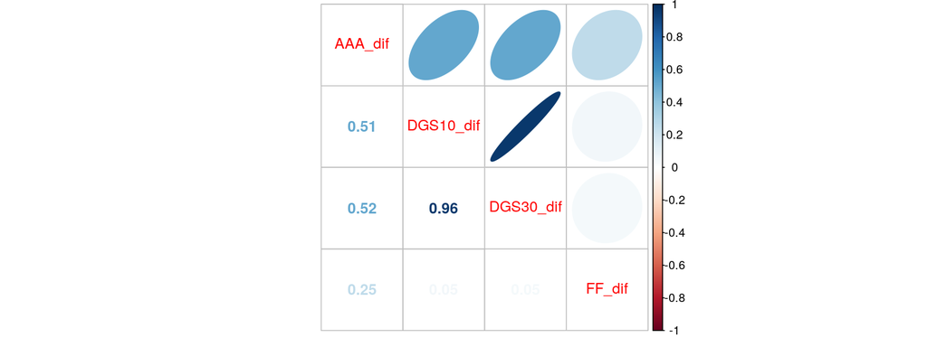

```r
rates <- data.frame(AAA_dif, DGS10_dif, DGS30_dif, FF_dif)
library(corrplot)
corrplot.mixed(cor(rates),upper="ellipse")
```

```r
summary(lm(AAA_dif ~ DGS10_dif+FF_dif))
```

```
Call:
lm(formula = AAA_dif ~ DGS10_dif + FF_dif)

Residuals:
     Min       1Q   Median       3Q      Max
-0.45001 -0.04550  0.00145  0.04768  0.60806

Coefficients:
              Estimate Std. Error t value Pr(>|t|)
(Intercept) -0.0005521  0.0036545  -0.151     0.88
DGS10_dif    0.3156957  0.0176225  17.914  < 2e-16 ***
FF_dif       0.0674802  0.0084737   7.964 5.17e-15 ***
---
Signif. codes:  0 ‘***’ 0.001 ‘**’ 0.01 ‘*’ 0.05 ‘.’ 0.1 ‘ ’ 1

Residual standard error: 0.1084 on 877 degrees of freedom
Multiple R-squared:  0.3137,	Adjusted R-squared:  0.3122
F-statistic: 200.5 on 2 and 877 DF,  p-value: < 2.2e-16
```

```r
summary(lm(AAA_dif ~ DGS10_dif+DGS30_dif+FF_dif))
```

```
Call:
lm(formula = AAA_dif ~ DGS10_dif + DGS30_dif + FF_dif)

Residuals:
     Min       1Q   Median       3Q      Max
-0.44083 -0.04746  0.00176  0.04788  0.61805

Coefficients:
              Estimate Std. Error t value Pr(>|t|)
(Intercept) -0.0005413  0.0036369  -0.149  0.88171
DGS10_dif    0.1298585  0.0627883   2.068  0.03891 *
DGS30_dif    0.2147151  0.0696579   3.082  0.00212 **
FF_dif       0.0676681  0.0084331   8.024 3.27e-15 ***
---
Signif. codes:  0 ‘***’ 0.001 ‘**’ 0.01 ‘*’ 0.05 ‘.’ 0.1 ‘ ’ 1

Residual standard error: 0.1079 on 876 degrees of freedom
Multiple R-squared:  0.3211,	Adjusted R-squared:  0.3188
F-statistic: 138.1 on 3 and 876 DF,  p-value: < 2.2e-16
```

- When two or more **predictors** are highly correlated with each other, it is difficult to evaluate their separate effects on the response variable
- This problem is called **"collinearity"** (if only two predictors are affected) or **"multicollinearity"** (if more than two predictors are involved)
- Collinearity causes the following issues:

  (1) Adding the collinear predictors only slightly increase the predictive power of the model (as measured by adjusted R$^2$ or other criteria).

  (2) Regression coefficients of collinear predictors are very sensitive to whether the other variable(s) are included.

  (3) The variance of the estimated coefficients become much larger after adding collinear predictors. This is called **"variance inflation"**.
- How to detect (multi)collinearity?
- Scatter (or correlation) plots of predictors against each other is very helpful to detect collinearity between two predictors.
- Multicollinearity, however, is harder to detect using scatter plots (since it involves three or more predictors)
- A better measure of collinearity is the **"variance inflation factor (VIF)"**
- Suppose we have predictors $X_1,\ldots,X_p$. The VIF of X_j tells us how much the variance of $\betah_j$ increases if we add the other predictors.
- More specifically, $VIF_j=\displaystyle\frac{\Var(\betah_j)}{\Var(\betah_j')}$

  where $\betah_j$ is the estimated regression coefficient when all the predictors are used, and $\betah_j'$ is the estimated regression coefficient in a model that only includes $X_j$
- It can be shown that $VIF_j=\displaystyle\frac{1}{1-\text{R}^2_j}$

  where R$^2_j$ is the R$^2$ obtained by regressing $X_j$ on the other $p-1$ predictors that is

  $\displaystyle X_{n,j} = \tht_0+\sum_{k\ne j} \tht_{j,k} X_{n,k} + \eps_n$
- Note that the values of VIF do not depend on the response variable $\{Y_{n}\}$. Also, $\text{VIF}_j\ge1$
- The remedy to collinearity is to reduce the number of predictors. Simply use a model selection criterion (e.g. adj. R$^2$, AIC, or BIC) to find a parsimonious model
- We can use the R function `vif()` in the `faraway` package to calculate VIF of predictors

```r
library(faraway)
options(digits=2)
vif(lm(AAA_dif~DGS10_dif+DGS30_dif+FF_dif))
```

**DGS10_dif**

12.8552486440663

**DGS30_dif**

12.84969239073

**FF_dif**

1.00297234341518

- `FF_dif` does not suffer from collinearity, its VIF takes the minimum value of 1
- The other two predictors are clearly collinear (their VIF value is much larger than 1)
- As we have seen before, a model selected based on BIC will only choose `FF_dif` and `DGS30_dif`, effectively eliminating collinearity
- This is not a clear-cut choice however. We may choose to keep `DGS10_dif` if we are using adjusted R$^2$. There may also be economical justification for keeping a predictor

# 2. Regression Diagnostic (Chapter 10)

- Many things can go wrong when a model is fitted to data. For example
  - Data may be presented incorrectly
  - The model assumptions may not be valid, or
  - The model might be too sensitive to the values of a small number of observations
- Never rely blindly on the result of a model. Always, compliment the results with graphical analyses and visual representation of Data
- There are two specific potential problems with regression models:
  1. **high-leverage points:** extreme predictor (that is $\Xv$) values
  2. **residual outlier:** extreme response (that is $\Yv$) values

```r
set.seed(99)
x = 1:11
x[11] = 50 # A high-leverage observation
y=1+x+rnorm(11)
y2 = y
y2[11] = 5.254
x2 = x
x2[11] = 5.5
model_a = lm(y~x)
model_b = lm(y2~x)
model_c = lm(y~x2)
cexx = c(rep(1.5,10),2)
col <- c(rep(4,10),2)
```

```r
# Setting parameters of the Jupyter notebook
sc = .75
options(repr.plot.width=16*sc,
        repr.plot.height=6*sc,
        repr.plot.pointsize = 20, # Text height in pt
        repr.plot.bg        = 'white',
        repr.plot.antialias = 'gray',
        #nice medium-res DPI
        repr.plot.res       = 300,
        #jpeg quality bumped from default
        repr.plot.quality   = 90,
        #vector font family
        repr.plot.family    = 'serif') # Vector font family. 'sans', 'serif', 'mono' or a specific one
```

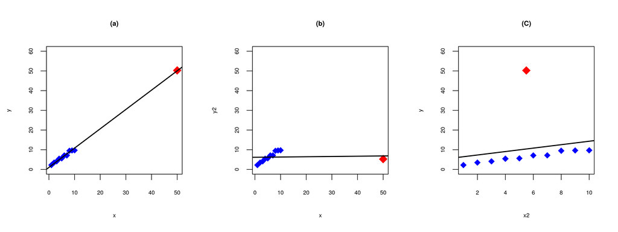

```r
par(mfrow=c(1,3))
plot(x,y,ylim=c(0,60),cex=cexx,pch=18,col=col,main="(a)")
abline(model_a,lwd=2)
plot(x,y2,ylim=c(0,60),cex=cexx,pch=18,col=col,ylab="y2",main="(b)")
abline(model_b,lwd=2)
plot(x2,y,ylim=c(0,60),cex=cexx,pch=18,col=col,xlab="x2",main="(C)")
abline(model_c,lwd=2)
```

# 3. Leverage plots

- Recall that

\begin{align*} \widehat{\Yv} = H \Yv \Longrightarrow \Yh_n = H_{nn} Y_n + \sum_{m\ne n} H_{nm}\,Y_m \end{align*}

- Here, the hat matrix $H = \Xv (\Xv^\top \Xv)^{-1} \Xv^\top$ only depends on the predictor values
- Also, note that

\begin{align*} \Cov\left(\widehat{\Yv}|\Xv\right) &= \Cov\left(H\,\Yv|\Xv\right) = H\, \Cov\left(\Yv|\Xv\right)\, H^\top \\ &= H\, \left(\sig_\eps^2 \Iv\right)\, H^\top = \sig_\eps^2 H\, H^\top = \sig_\eps^2 H \end{align*}

- In particular,

\begin{align*} \Var\left(\Yh_n|\Xv\right) = \sig_\eps^2\, H_{nn} \end{align*}

- $H_{nn}$ is called *the leverage* of the $n$-th observation
- Note that "high" values for $H_{nn}$ leads to
  1. Too much sensitivity of $\Yh_n$ on $Y_n$
  2. High variance for $\Yh_n$
- What do we mean by "high" values?
- It can be shown that
  - The average leverage value is $\frac{p+1}{N}$

    That is, $\frac{H_{11} + \dots + H_{NN}}{N} = \frac{p+1}{N}$
  - $0<H_{nn}<1$ for $n\in\{1,\dots, N\}$
- An observation whose leverage value is twice the average is considered a high-leverage point, i.e. if $H_{nn}>2\frac{p+1}{N}$
- To detect High leverage points, we use the **leverage plot**

```r
# Setting parameters of the Jupyter notebook
sc = .75
options(repr.plot.width=16*sc,
        repr.plot.height=6*sc,
        repr.plot.pointsize = 20, # Text height in pt
        repr.plot.bg        = 'white',
        repr.plot.antialias = 'gray',
        #nice medium-res DPI
        repr.plot.res       = 300,
        #jpeg quality bumped from default
        repr.plot.quality   = 90,
        #vector font family
        repr.plot.family    = 'serif') # Vector font family. 'sans', 'serif', 'mono' or a specific one
```

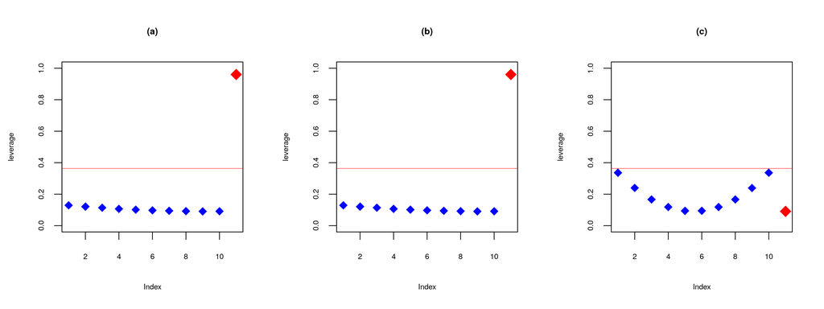

```r
par(mfrow=c(1,3))
plot(hatvalues(model_a), ylab="leverage",main="(a)", ylim=c(0,1),cex=cexx,col=col,pch=18)
abline(h=2*(2/11),lwd=0.5,col=2)
plot(hatvalues(model_b), ylab="leverage",main="(b)", ylim=c(0,1),cex=cexx,col=col,pch=18)
abline(h=2*(2/11),lwd=0.5,col=2)
plot(hatvalues(model_c), ylab="leverage",main="(c)", ylim=c(0,1),cex=cexx,col=col,pch=18)
abline(h=2*(2/11),lwd=0.5,col=2)
```

# 4. Externally studentized residuals (rstudent)

- Recall the example for high-leverage points and residual outliers

```r
set.seed(99)
x = 1:11
x[11] = 50 # A high-leverage observation
y=1+x+rnorm(11)
y2 = y
y2[11] = 5.254
x2 = x
x2[11] = 5.5
model_a = lm(y~x)
model_b = lm(y2~x)
model_c = lm(y~x2)
cexx = c(rep(1.5,10),2)
col <- c(rep(4,10),2)
# Setting parameters of the Jupyter notebook
sc = .75
options(repr.plot.width=16*sc,
        repr.plot.height=6*sc,
        repr.plot.pointsize = 20, # Text height in pt
        repr.plot.bg        = 'white',
        repr.plot.antialias = 'gray',
        #nice medium-res DPI
        repr.plot.res       = 300,
        #jpeg quality bumped from default
        repr.plot.quality   = 90,
        #vector font family
        repr.plot.family    = 'serif') # Vector font family. 'sans', 'serif', 'mono' or a specific one
```

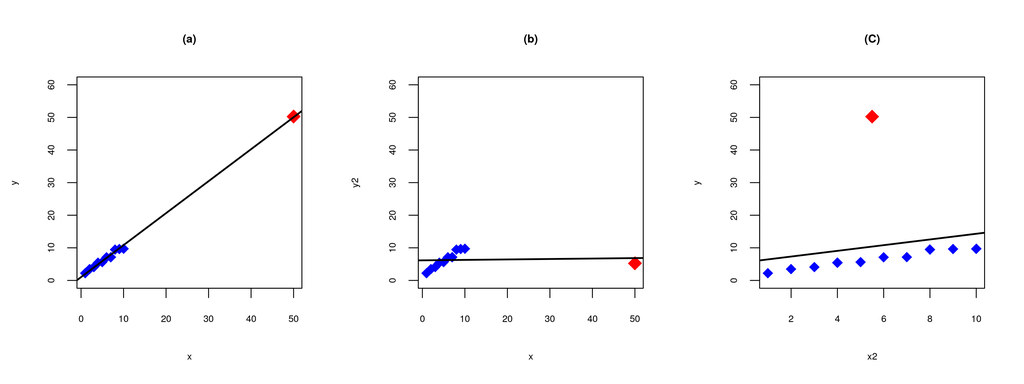

```r
par(mfrow=c(1,3))
plot(x,y,ylim=c(0,60),cex=cexx,pch=18,col=col,main="(a)");abline(model_a,lwd=2)
plot(x,y2,ylim=c(0,60),cex=cexx,pch=18,col=col,ylab="y2",main="(b)");abline(model_b,lwd=2)
plot(x2,y,ylim=c(0,60),cex=cexx,pch=18,col=col,xlab="x2",main="(C)");abline(model_c,lwd=2)
```

- We learned how to detect high-leverage points by using leverage plots

```r
# Setting parameters of the Jupyter notebook
sc = .75
options(repr.plot.width=16*sc,
        repr.plot.height=6*sc,
        repr.plot.pointsize = 20, # Text height in pt
        repr.plot.bg        = 'white',
        repr.plot.antialias = 'gray',
        #nice medium-res DPI
        repr.plot.res       = 300,
        #jpeg quality bumped from default
        repr.plot.quality   = 90,
        #vector font family
        repr.plot.family    = 'serif') # Vector font family. 'sans', 'serif', 'mono' or a specific one
```

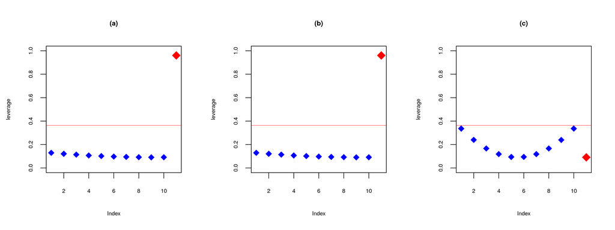

```r
par(mfrow=c(1,3))
plot(hatvalues(model_a), ylab="leverage",main="(a)", ylim=c(0,1),cex=cexx,col=col,pch=18)
abline(h=2*(2/11),lwd=0.5,col=2)
plot(hatvalues(model_b), ylab="leverage",main="(b)", ylim=c(0,1),cex=cexx,col=col,pch=18)
abline(h=2*(2/11),lwd=0.5,col=2)
plot(hatvalues(model_c), ylab="leverage",main="(c)", ylim=c(0,1),cex=cexx,col=col,pch=18)
abline(h=2*(2/11),lwd=0.5,col=2)
```

- Q: How to detect residual outliers?
- Under ideal circumstances, the "raw" residuals $\epsh_n = Y_n - \Yh_n$ are approximately i.i.d. $N(0,\sig_{\eps}^2)$
- So, values of $|\epsh_n|$ greater than, say, $3\sig_{\eps}$ can be considered residual outliers
- However, Residual outlier at high-leverage points are not detectable by looking at raw residuals
- The problem is that such residuals have small size

```r
# Setting parameters of the Jupyter notebook
sc = .75
options(repr.plot.width=16*sc,
        repr.plot.height=6*sc,
        repr.plot.pointsize = 20, # Text height in pt
        repr.plot.bg        = 'white',
        repr.plot.antialias = 'gray',
        #nice medium-res DPI
        repr.plot.res       = 300,
        #jpeg quality bumped from default
        repr.plot.quality   = 90,
        #vector font family
        repr.plot.family    = 'serif') # Vector font family. 'sans', 'serif', 'mono' or a specific one
```

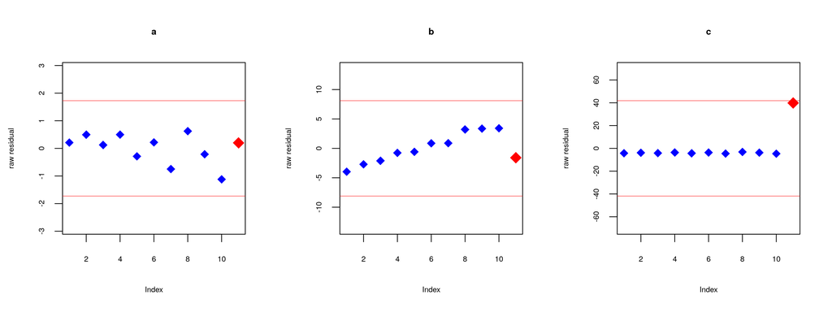

```r
par(mfrow=c(1,3))
models = list(a=model_a, b=model_b, c=model_c)
for(i in 1:length(models)){
  model = models[[i]]
  sigma = summary(model)$sigma
  minresid = min(resid(model))
  maxresid = max(resid(model))
  plot(resid(model), ylim = c(min(-5*sigma, minresid), max(5*sigma, maxresid)),
       ylab="raw residual",main=names(models)[i],cex=cexx,col=col, pch=18)
  abline(h=c(-3*sigma, 3*sigma),lwd=0.5,col=2)
}
```

- Note that,

\begin{align*} \Cov\left(\epsvh\right) &= \Cov\left(\Yv - \Yvh\right) = \Cov\left(\Yv - H \Yv\right)\\ &= (I-H)\Cov\left(\Yv\right)(I-H)^\top = \sig^2_\eps(I-H)(I-H) = \sig^2_\eps(I-H). \end{align*}

- Recall that $H = \Xv\left(\Xv^\top\Xv\right)^{-1}\Xv^\top$ is the hat matrix. In particular, $\Var(\epsh_n) = \sig^2_\eps (1-H_{nn})$.
- To account for the small size of $\epsh_n$ at high-leverage points, we "studentize" the residuals by dividing by their standard error,

\begin{align*} \text{Internally studentized residuals} := \frac{\epsh_n}{\sigh_\eps\sqrt{1-H_{nn}}} \end{align*}

```r
# Setting parameters of the Jupyter notebook
sc = .75
options(repr.plot.width=16*sc,
        repr.plot.height=6*sc,
        repr.plot.pointsize = 20, # Text height in pt
        repr.plot.bg        = 'white',
        repr.plot.antialias = 'gray',
        #nice medium-res DPI
        repr.plot.res       = 300,
        #jpeg quality bumped from default
        repr.plot.quality   = 90,
        #vector font family
        repr.plot.family    = 'serif') # Vector font family. 'sans', 'serif', 'mono' or a specific one
```

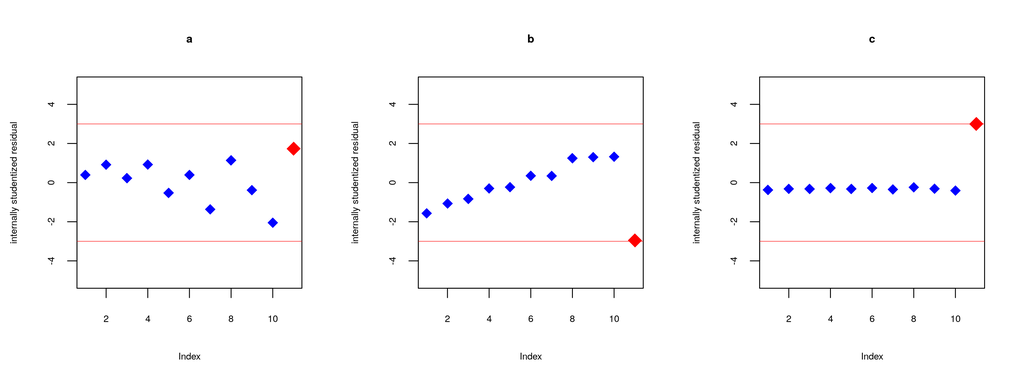

```r
par(mfrow=c(1,3))
for(i in 1:length(models)){
  model = models[[i]]
  sigma = summary(model)$sigma
  intrstudent = resid(model)/sigma/sqrt(1-hatvalues(model))
  min_intrstudent = min(intrstudent)
  max_intrstudent = max(intrstudent)
  plot(intrstudent, ylim = c(min(-5, min_intrstudent), max(5, max_intrstudent)),
       ylab="internally studentized residual",main=names(models)[i],cex=cexx,col=col, pch=18)
  abline(h=c(-3, 3),lwd=0.5,col=2)
}
```

- However, internally studentized residuals still have a problem
- A residual outlier inflates $\sigh_\eps^2$, which makes internally studentized residuals to be small
- To take this into account, we exclude each observation when studentizing it
- The resulting residual is called "the externally studentized residual" or **rstudent**

\begin{align*} \text{rstudent}_n := \frac{\epsh_n}{\sigh_{\eps,(-n)}\sqrt{1-H_{nn}}} \end{align*}

- Here, $\sigh_{\eps,(-n)}$ is the residual standard error for a regression model which uses all but the n-th observation $(X_{n,1},\dots,X_{n,p}, Y_n)$

```r
# Setting parameters of the Jupyter notebook
sc = .75
options(repr.plot.width=16*sc,
        repr.plot.height=6*sc,
        repr.plot.pointsize = 20, # Text height in pt
        repr.plot.bg        = 'white',
        repr.plot.antialias = 'gray',
        #nice medium-res DPI
        repr.plot.res       = 300,
        #jpeg quality bumped from default
        repr.plot.quality   = 90,
        #vector font family
        repr.plot.family    = 'serif') # Vector font family. 'sans', 'serif', 'mono' or a specific one
```

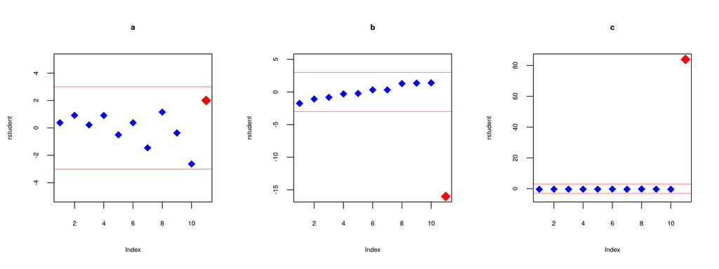

```r
par(mfrow=c(1,3))
for(i in 1:length(models)){
  model = models[[i]]
  sigma = summary(model)$sigma
  min_rstudent = min(rstudent(model))
  max_rstudent = max(rstudent(model))
  plot(rstudent(model), ylim = c(min(-5, min_rstudent), max(5, max_rstudent)),
       ylab="rstudent",main=names(models)[i],cex=cexx,col=col, pch=18)
  abline(h=c(-3, 3),lwd=0.5,col=2)
}
```

- **Bottom line:** Always use externally studentized residuals (rstudent) for regression diagnostic

# 5. Cook's distance (Cook's D)

- Values of leverage and rstudent can indicate potential problems. But, they don't tell us how much influence an observation has on estimates
- This information can be obtained by Cook's D
- Let $\Yh_k(-n)$ be the $k$-th fitted value using $\betah$-s that are estimated with the $n$-th observation excluded
- Cook's D for the $n$-the observation is

\begin{align*} \text{Cook's D}_n := \frac{\sum_{k=1}^N \left(\Yh_k - \Yh_k(-n)\right)^2}{\sigh_\eps^2(p+1)} \end{align*}

- Cook's D measures how much (on average) the fitted values change if an observation is deleted
- It directly measures the *influence* of an observation
- Observations with high Cook's D are called *"high-influence"* points (or observations)
- To find high influence points, we should find outliers in Cook's D
- Finding outliers may not be easy, however!

```r
# Setting parameters of the Jupyter notebook
sc = .75
options(repr.plot.width=16*sc,
        repr.plot.height=6*sc,
        repr.plot.pointsize = 20, # Text height in pt
        repr.plot.bg        = 'white',
        repr.plot.antialias = 'gray',
        #nice medium-res DPI
        repr.plot.res       = 300,
        #jpeg quality bumped from default
        repr.plot.quality   = 90,
        #vector font family
        repr.plot.family    = 'serif') # Vector font family. 'sans', 'serif', 'mono' or a specific one
```

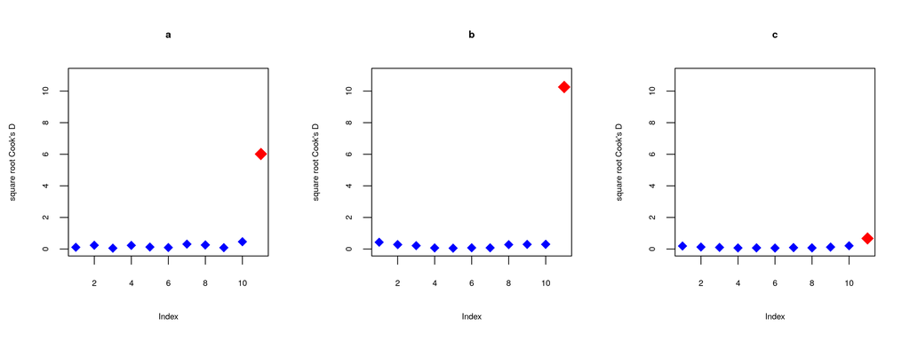

```r
par(mfrow=c(1,3))
models = list(a=model_a, b=model_b, c=model_c)
for(i in 1:length(models)){
  model = models[[i]]
  plot(sqrt(cooks.distance(model)), ylim = c(0,11),
       ylab=("square root Cook's D"), main=names(models)[i],cex=cexx,col=col, pch=18)
}
```

- A **half-normal plot** is a good graphical tool to detect outliers in a sample
- A half-normal plot is the QQ plot of the sample quantiles of the absolute value of a sample against the quantile of $|Z|$, where $Z\sim N(0,1)$
- To detect high influence points, we use the half-normal plots of the square root of Cook's D statistics
- The main use of half-normal plots is to detect outliers, not to compare distributions
- Look for points that are "detached" from the rest of the sample
- Non-linearity does not matter

```r
# Setting parameters of the Jupyter notebook
sc = .75
options(repr.plot.width=16*sc,
        repr.plot.height=6*sc,
        repr.plot.pointsize = 20, # Text height in pt
        repr.plot.bg        = 'white',
        repr.plot.antialias = 'gray',
        #nice medium-res DPI
        repr.plot.res       = 300,
        #jpeg quality bumped from default
        repr.plot.quality   = 90,
        #vector font family
        repr.plot.family    = 'serif') # Vector font family. 'sans', 'serif', 'mono' or a specific one
```

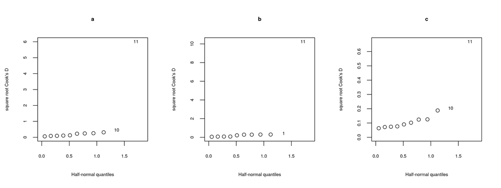

```r
par(mfrow=c(1,3))
library(faraway) # needed for half normal plots
models = list(a=model_a, b=model_b, c=model_c)
for(i in 1:length(models)){
  model = models[[i]]
  halfnorm(sqrt(cooks.distance(model)), xlim=c(0,1.85),
           ylab=("square root Cook's D"), main=names(models)[i])
}
```

# 6. Checking model assumptions

- Recall that our main assumption for a linear regression model is that $\eps_n\overset{i.i.d.}{\sim}N(0,\sig_\eps^2)$
- Since the $n$-th residual $\epsh_n:=Y_n-\Yh_n$ is an estimate of the $n$-th error $\eps_n$, we can use the residuals to check the validity of the model assumptions
- Problems to look for in a linear regression model:
  - non-normality of the errors
  - non-constant variance of the errors
  - non-linearity of the effects of predictors on the response
  - Correlation (i.e. dependence) of the error terms
- Next, we briefly discuss how to detect the these problems by *"residual analysis"*
- This analysis is generally conducted by various plots of residuals, each designed to highlight one or more of the problems
- Always use the **externally studentized residuals (rstudent)** for residual analysis!

## 6.1. Non-normality

- A good way of detecting non-normality of residuals is a normal-probability plot of rstudent
- An accompanying histogram or KDE is also helpful to identify the problem
- In most financial data, residuals are non-normal because of too many outliers, i.e. they are heavy-tailed
- Always check if the outliers are the result of an error in data entry.
- If they were, correct them or remove them. If they are genuine data, never eliminate them!
- In case of outliers that are genuine data, a good practice is to repeat your analysis with the outliers removed. If the end result of your analysis does not change after removing the outliers, you will be more confident that the model your are using is relevant. However, if the result changed after removing the outliers, then it is an indication that your model is too simple, and you should use a model that better fits the data.
- Recall the government v.s. corporate lending rate example from the previous lecture

```r
library(quantmod)
getSymbols(c("WAAA","DGS30", "FF"), src="FRED")
dat <- na.locf(merge(WAAA,DGS30,FF))[index(WAAA)]["1977-02-16/1993-12-31"]
AAA_dif = diff(as.vector(dat[,"WAAA"]))
DGS30_dif = diff(as.vector(dat[,"DGS30"]))
FF_dif = diff(as.vector(dat[,"FF"]))
fit <- lm(AAA_dif ~ FF_dif+DGS30_dif)
```

1. 'WAAA'

2. 'DGS30'

3. 'FF'

```r
# Setting parameters of the Jupyter notebook
sc = .75
options(repr.plot.width=16*sc,
        repr.plot.height=6*sc,
        repr.plot.pointsize = 20, # Text height in pt
        repr.plot.bg        = 'white',
        repr.plot.antialias = 'gray',
        #nice medium-res DPI
        repr.plot.res       = 300,
        #jpeg quality bumped from default
        repr.plot.quality   = 90,
        #vector font family
        repr.plot.family    = 'serif') # Vector font family. 'sans', 'serif', 'mono' or a specific one
```

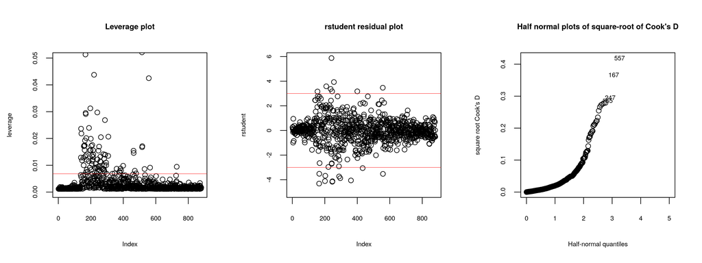

```r
# Leverage plot, Residual plot, and Half normal plot of square-root of Cook's D
par(mfrow=c(1,3))
plot(hatvalues(fit), ylab="leverage",main="Leverage plot", ylim=c(0,.05))
p=2;n=length(AAA_dif);
abline(h=2*((p+1)/n),lwd=0.5,col=2)

sigma = summary(fit)$sigma
min_rstudent = min(rstudent(fit))
max_rstudent = max(rstudent(fit))
plot(rstudent(fit), ylim = c(min(-5, min_rstudent), max(5, max_rstudent)),
     ylab="rstudent",main="rstudent residual plot")
abline(h=c(-3, 3),lwd=0.5,col=2)

halfnorm(sqrt(cooks.distance(fit)), xlim=c(0,5), nlab = 4,
         ylab=("square root Cook's D"), main="Half normal plots of square-root of Cook's D")
```

- Using a normal plot to detect non-normality

```r
# Setting parameters of the Jupyter notebook
sc = .75
options(repr.plot.width=16*sc,
        repr.plot.height=7*sc,
        repr.plot.pointsize = 20, # Text height in pt
        repr.plot.bg        = 'white',
        repr.plot.antialias = 'gray',
        #nice medium-res DPI
        repr.plot.res       = 300,
        #jpeg quality bumped from default
        repr.plot.quality   = 90,
        #vector font family
        repr.plot.family    = 'serif') # Vector font family. 'sans', 'serif', 'mono' or a specific one
```

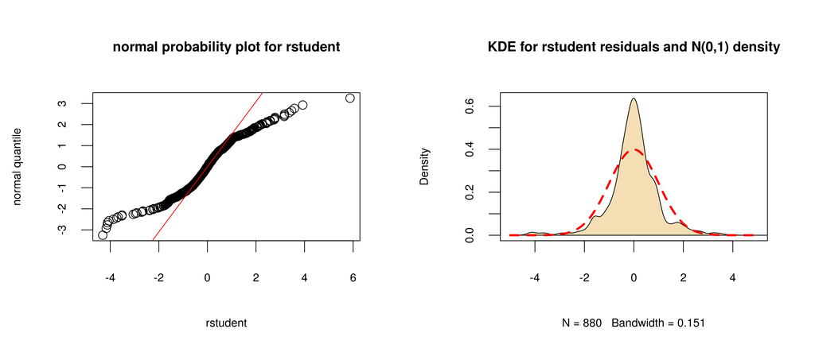

```r
par(mfrow=c(1,2))
qqnorm(rstudent(fit), datax = TRUE,
       xlab = "normal quantile", # this is for the theoretical quantiles
       ylab = "rstudent", # this is for the sample quantiles
       main = "normal probability plot for rstudent")
qqline(rstudent(fit), datax=TRUE, col = 2)
d <- density(rstudent(fit), adjust = 1, na.rm = TRUE)
plot(d, type = "n", xlim=c(-5,5), main="KDE for rstudent residuals and N(0,1) density") # more sophisticated plot
polygon(d, col = "wheat")
z = seq(from=-5,to=5,by=.01)
lines(z,dnorm(z), lty=2,lwd=3,col="red")
```

## 6.2. Non-constant variance

- The variance of error may change between observations, that is, $\Var(\eps_n)=\sig_n^2$
- Financial data often have the property that larger responses are more variable
- To detect non-constant variance, plot the absolute value of rstudent against the fitted values
- An increasing (or other systematic) trend is an indication of non-constant variance
- A scatter plot smoother such as *"loess"* (a non-parametric regression model) are usually included to highlight trends
- To remedy non-constant variance, we may transform the data or use regression models with GARCH error, which we will study later in the course

```r
# Setting parameters of the Jupyter notebook
sc = 1.25
options(repr.plot.width=6*sc,
        repr.plot.height=6*sc,
        repr.plot.pointsize = 20, # Text height in pt
        repr.plot.bg        = 'white',
        repr.plot.antialias = 'gray',
        #nice medium-res DPI
        repr.plot.res       = 70,
        #jpeg quality bumped from default
        repr.plot.quality   = 90,
        #vector font family
        repr.plot.family    = 'serif') # Vector font family. 'sans', 'serif', 'mono' or a specific one
```

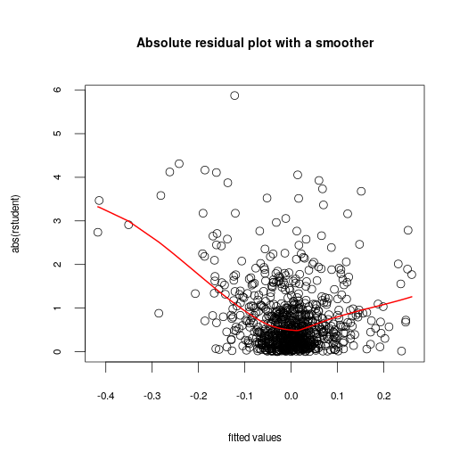

```r
plot(fitted(fit), abs(rstudent(fit)),
     xlab = "fitted values", ylab = "abs(rstudent)",
     main = "Absolute residual plot with a smoother")
smoother = loess(abs(rstudent(fit)) ~ fitted(fit))
ord = order(fitted(fit)) # why do we need this line?
lines(fitted(fit)[ord], fitted(smoother)[ord], col="red", lwd=2)
#Try this: lines(fitted(fit), fitted(smoother), col="red", lwd=2)
```

## 6.3. Nonlinearity

- To detect nonlinear relationship between response and predictors, plot rstudent against predictor values
- A systematic nonlinear trend in this plot indicates that the effect of predictors on response is nonlinear
- As in the case of non-constant variance, using a scatter plot smoother helps to highlight trends

```r
# Setting parameters of the Jupyter notebook
sc = .75
options(repr.plot.width=16*sc,
        repr.plot.height=7*sc,
        repr.plot.pointsize = 20, # Text height in pt
        repr.plot.bg        = 'white',
        repr.plot.antialias = 'gray',
        #nice medium-res DPI
        repr.plot.res       = 300,
        #jpeg quality bumped from default
        repr.plot.quality   = 90,
        #vector font family
        repr.plot.family    = 'serif') # Vector font family. 'sans', 'serif', 'mono' or a specific one
```

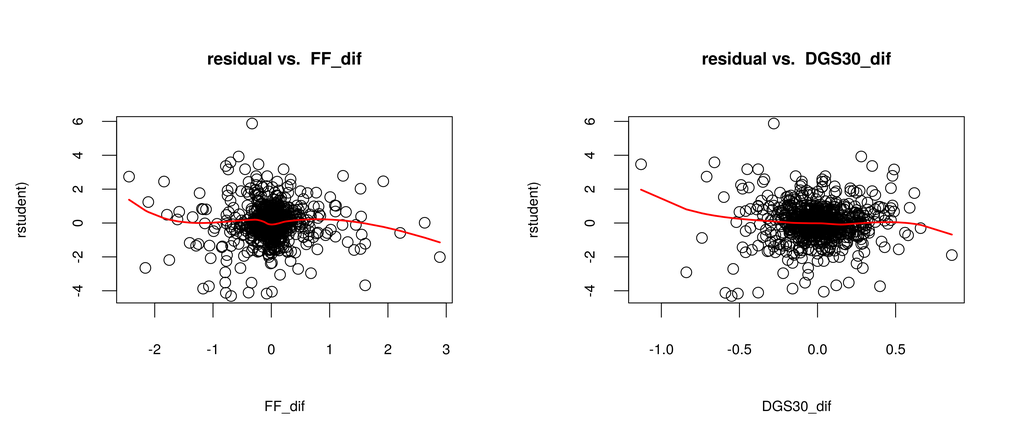

```r
par(mfrow=c(1,2))
preds = list(FF_dif, DGS30_dif);labs = list("FF_dif", "DGS30_dif")
for (p in 1:length(preds)) {
  X = preds[[p]]
  plot(X, rstudent(fit),
       xlab = labs[[p]], ylab = "rstudent)",
       main = paste("residual vs. ", labs[[p]]))
  smoother = loess(rstudent(fit) ~ X); ord = order(X)
  lines(X[ord], fitted(smoother)[ord], col="red", lwd=2)
}
```

Next time, explain the following:

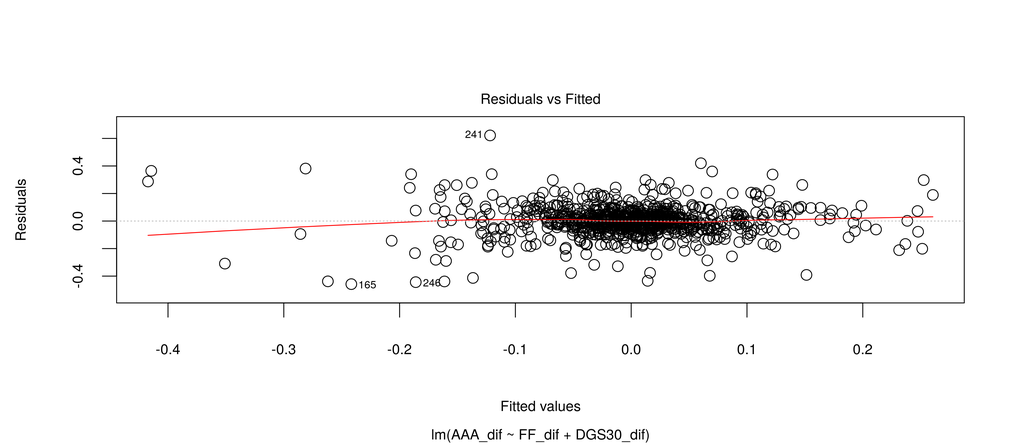

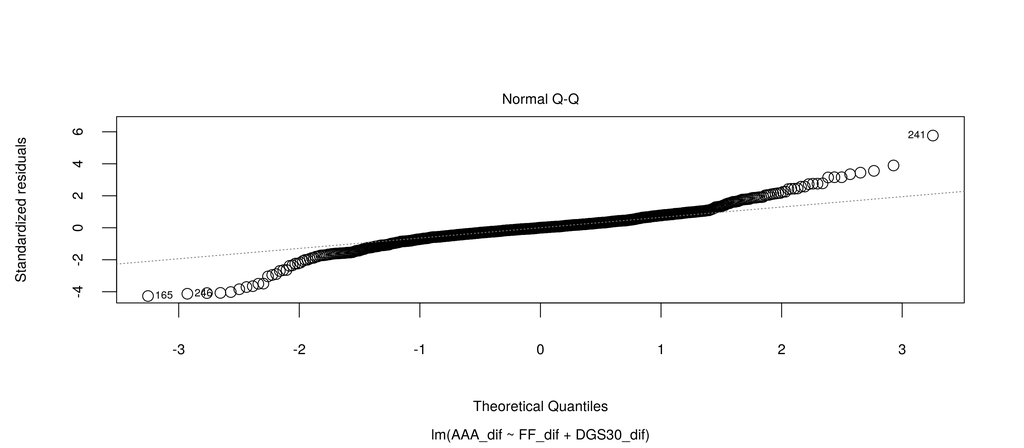

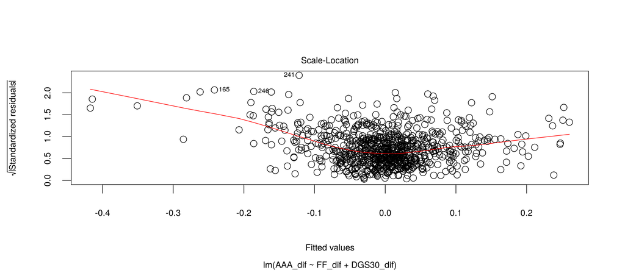

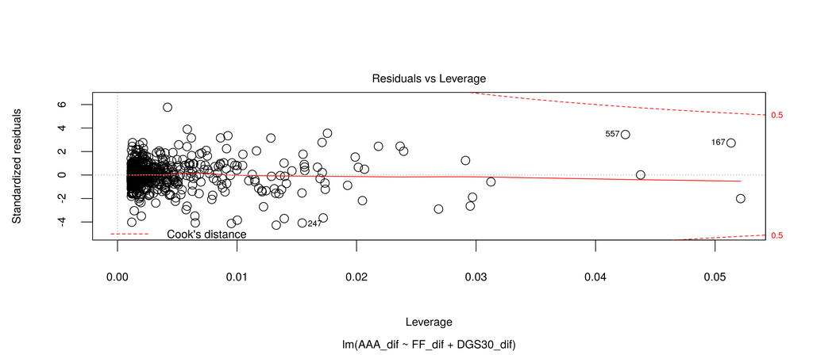

```r
plot(fit)
```

# 6.4. Residual correlation and spurious regression

- Many of the significance tests that we have encountered "heavily rely" on the assumption that the noise in the sample is independent
- If the noise term in a sample, that is, the random variables $\eps_1,\ldots, \eps_N$, are highly correlated, it is very likely to obtain highly significant results for the coefficients even if their actual value is zero. This phenomenon is called **"spurious regression"**
- Let us illustrate by a numerical example of spurious regression
- Assume that $\{U_1,\ldots,U_N\}$ and $\{V_1,\ldots,V_N\}$ are two sequence of independent standard normal random variables

```r
N=350
set.seed(99)
U = rnorm(N)
V = rnorm(N)
```

- Next, we obtain a sample $(X_0, Y_0), \ldots, (X_N,Y_N)$ as follows

\begin{align*} X_0&=1,\quad X_n=X_{n-1}+U_n=U_1+\ldots+U_n\\ Y_0&=1,\quad Y_n=Y_{n-1}+V_n=V_1+\ldots+V_n \end{align*}

```r
X = c(1,1+cumsum(U))
Y = c(1,1+cumsum(V))
```

```r
# Setting parameters of the Jupyter notebook
sc = 1
options(repr.plot.width=10*sc, repr.plot.height=5*sc)
```

- Simple visualizations of the sample $\{(X_n,Y_n)\}_{n=0}^N$

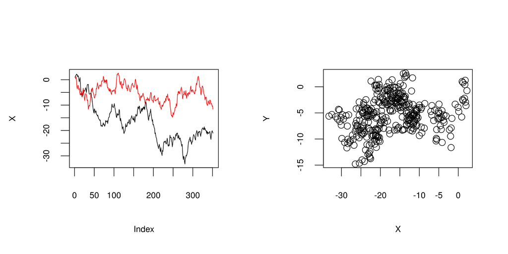

```r
par(mfrow=c(1,2))
plot(X, type = "l", ylim = c(min(X,Y), max(X,Y)))
lines(Y, type = "l", col=2)
plot(X,Y)
```

- Do you think that $X_n$ can predict $Y_n$?
- The answer is negative, since $X_n$ and $Y_n$ are independent. (why?)
- So, the coefficient $\beta_1$ in the linear regression model

  $Y_n=\beta_0 + \beta_1 X_n + \eps_n$

  must be zero.
- Let us fit a regression model to the sample

```r
spreg = lm(Y~X)
summary(spreg)
```

```
Call:
lm(formula = Y ~ X)

Residuals:
   Min     1Q Median     3Q    Max
-8.361 -2.386  0.125  2.390  7.563

Coefficients:
            Estimate Std. Error t value Pr(>|t|)
(Intercept)  -3.3718     0.4387   -7.69  1.6e-13 ***
X             0.1155     0.0237    4.88  1.6e-06 ***
---
Signif. codes:  0 ‘***’ 0.001 ‘**’ 0.01 ‘*’ 0.05 ‘.’ 0.1 ‘ ’ 1

Residual standard error: 3.3 on 349 degrees of freedom
Multiple R-squared:  0.064,	Adjusted R-squared:  0.0613
F-statistic: 23.9 on 1 and 349 DF,  p-value: 1.59e-06
```

- The estimated $\betah_1$ is small, but highly significant!
- Thus, the t-test does not seem to be correct. What went wrong? How can we detect the cause?
- As mentioned earlier, the t-test depends on the assumption that residuals are uncorrelated. We can check this by looking at the sample **"autocorrelation" function (ACF) plot**
- ACF plots will be discussed later in the course. Briefly speaking, the value of the ACF function at lag $k$ is an estimate of **autocorrelation** $\rho(k)$ which is the correlation between $\eps_n$ and $\eps_{n+k}$ for all $n$

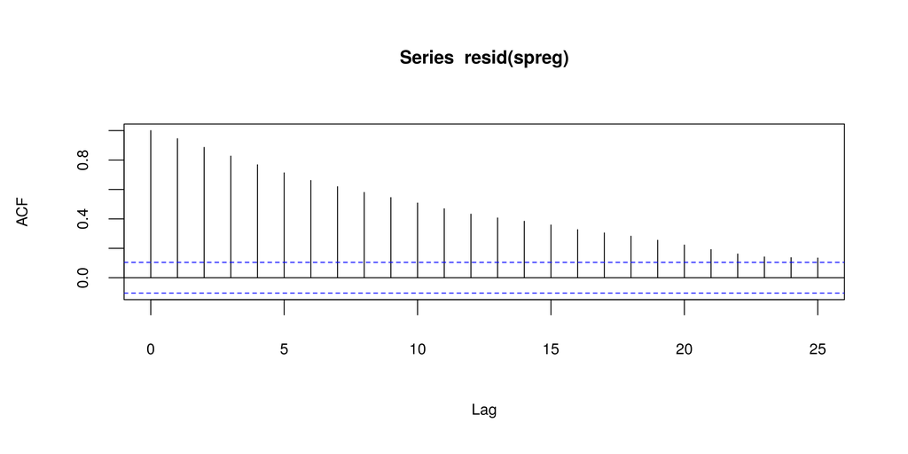

```r
acf(resid(spreg))
```

- As you can see, the values of ACF are large for lags up to 25
- ACF plots also includes a test for the hypothesis $H_0: \rho(k)=0$. If the value of ACF is within the band represented by the two dashed blue lines, $H_0$ is accepted. Otherwise, it is rejected
- In this case, autocorrelation is significant at many levels. This indicates that the residuals are highly correlated. Thus, the assumption of uncorrelated residuals is violated. That is why the tests are not working.
- To check the assumption of uncorrelated residuals, we can use the ACF plot of the residuals (or rstudent)
- Let us check this for the government v.s. corporate lending rate example. The ACF of the rstudent is as follows

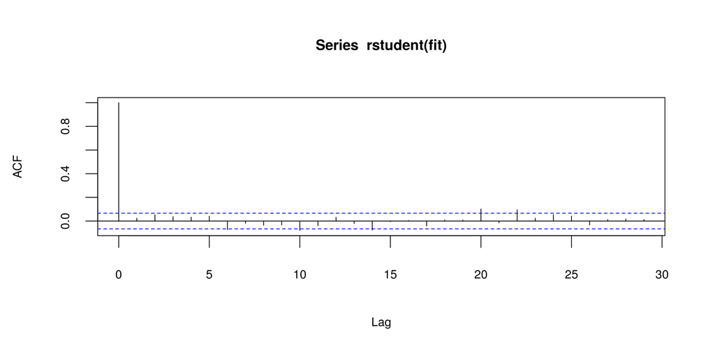

```r
acf(rstudent(fit))
```

- The ACF function has small values and mostly insignificant, that is, $H_0:\rho(k)=0$ is accepted for many k. This indicates that the residuals are uncorrelated.
- There are better statistical test for determining if a sample is uncorrelated or not, which we will discuss later in the course.